# Visualising dog morphology

In this activity we’ll revisit the dog morphology data set, and create some plots using `ggplot()`

We begin by loading some packages

```r
library("readxl")
library("dplyr")
library("stringr")
library("janitor")
library("tidyr")
library("ggplot2")
```

(Note we do not show the messages that get printed when the packages are loaded.)

## Dog morphology

In the third part of the activity, we will briefly look at a data set of information on the morphology of dog breeds. Again, the data are somewhat messy and need a little cleaning before we can begin working with them.

The data are in two separate sheets within the the `dog-morphology.xlsx` Excel workbook. First we have skull length and width measurements on several males and females from a number of dog breeds.

We load the data from the `CephalicIndex` sheet, clean the variable names, and then change the `sex` variable to have nice labels. Copy and paste this code into your script, but make sure you understand what each line is doing before you run the code:

```r
dog_skull <-  read_xlsx("data/dog-morphology/dog-morphology.xlsx",
  sheet = "CephalicIndex") |>
  janitor::clean_names() |>
  mutate(
    sex = case_when(
      sex == "M" ~ "male",
      sex == "F" ~ "female"
    )
  )
```

```r
dog_hw <- read_xlsx("data/dog-morphology/dog-morphology.xlsx",
  sheet = "HeightWeight") |>
  janitor::clean_names() |>
  rename(
    weight_lower_male = weight_range_male_lowest_and_highest,
    weight_upper_male = x4,
    weight_lower_female = weight_range_female,
    weight_upper_female = x6,
    height_lower_male = height_range_male,
    height_upper_male = x9,
    height_lower_female = height_range_female,
    height_upper_female = x11,
  )
```

We need to the average height and weight for male and female dogs of each breed to the `dog_hw` data frame, and create `sex` and `height` and `weight` columns:

```r
dog_hw <- dog_hw |>
  mutate(
    male_weight = (weight_lower_male + weight_upper_male) / 2,
    male_height = (height_lower_male + height_upper_male) / 2,
    female_weight = (weight_lower_female + weight_upper_female) / 2,
    female_height = (height_lower_female + height_upper_female) / 2
  )  |>
  select(breed, starts_with("male"), starts_with("female")) |>
  pivot_longer(
    !breed,
    names_to = c("sex", "variable"),
    names_sep = "_",
    values_to = "value"
  ) |>
  pivot_wider(
    id_cols = c(breed, sex),
    names_from = "variable",
    values_from = "value"
  )
```

**Question**

Produce a scatter plot of `skull_length` on the $x$ axis and `skull_width()` on the $y$ axis

## Solution

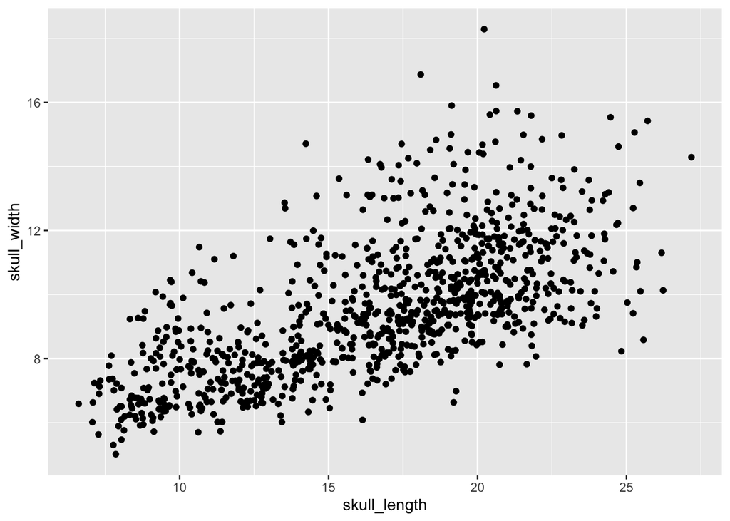

```r
dog_skull |>
  ggplot(aes(x = skull_length, y = skull_width)) +
  geom_point()
```

**Question**

How would you modify the previous plot to show the `sex` variable using colour?

## Solution

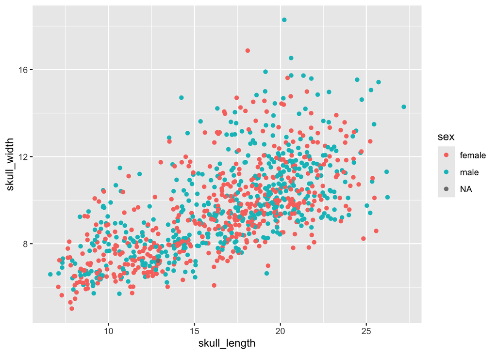

```r
dog_skull |>
  ggplot(aes(x = skull_length, y = skull_width, colour = sex)) +
  geom_point()
```

**Question**

How would you modify the original plot to use different shapes for `sex` and colour the points blue?

## Solution

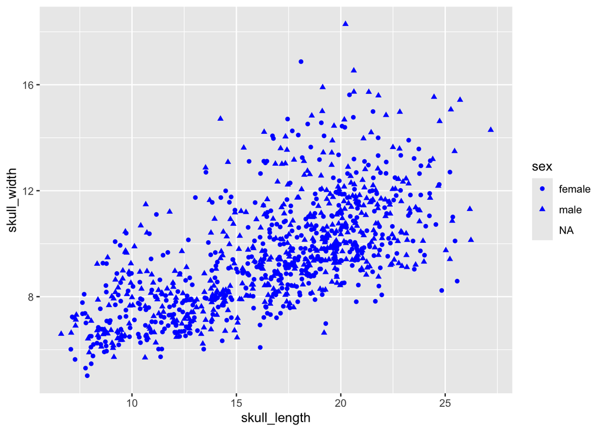

```r
dog_skull |>
  ggplot(aes(x = skull_length, y = skull_width, shape = sex)) +
  geom_point(colour = "blue")
```

**Question**

Take a look at the `dog_skull` data and choose five (5) breeds you are familiar with (or like the look of).

Filter the data to retain just your chosen five breeds and plot the length and width of each skull for this subset. Use colour to differentiate between breeds.

## Solution

I’m not very familiar with dog breeds, so I chose my breeds randomly

```r
set.seed(42)
breeds_want <- dog_skull |>
  distinct(breed) |>
  slice_sample(n = 5) |>
  pull(breed)
```

Then I filter the data

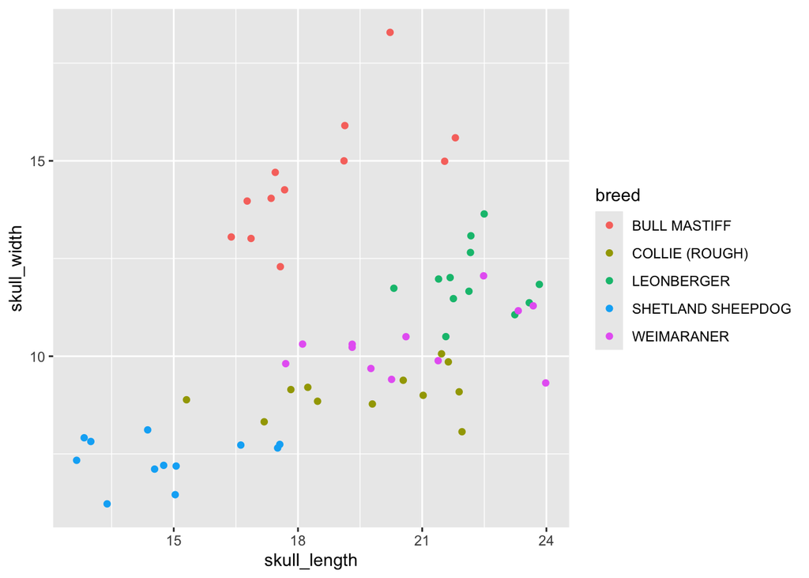

```r
dog_skull |>
  filter(breed %in% breeds_want) |>
  ggplot(aes(x = skull_length, y = skull_width, colour = breed)) +
  geom_point()
```

**Question**

Using `dog_hw`, create a scatter plot of `height` on the $x$ axis and `weight` on the $y$ axis.

## Solution

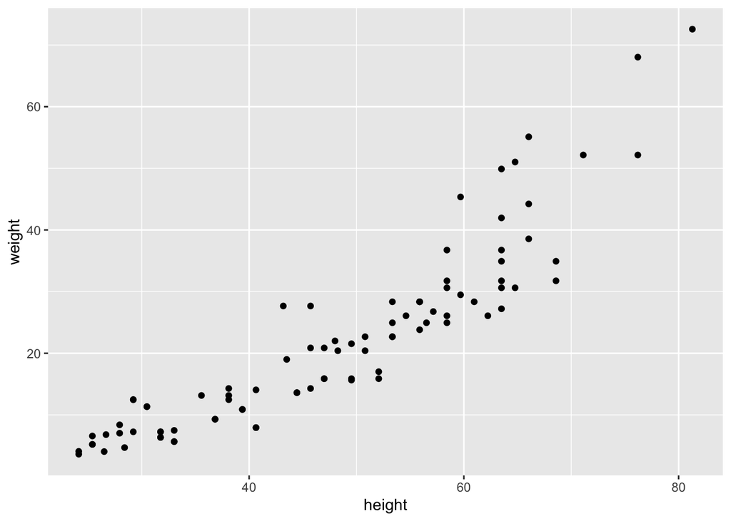

```r
dog_hw |>
  ggplot(aes(x = height, y = weight)) +
  geom_point()
```

**Question**

Modify the previous plot to include:

- colour by `sex`
- fill by `sex`
- add linear regression lines per sex

## Solution

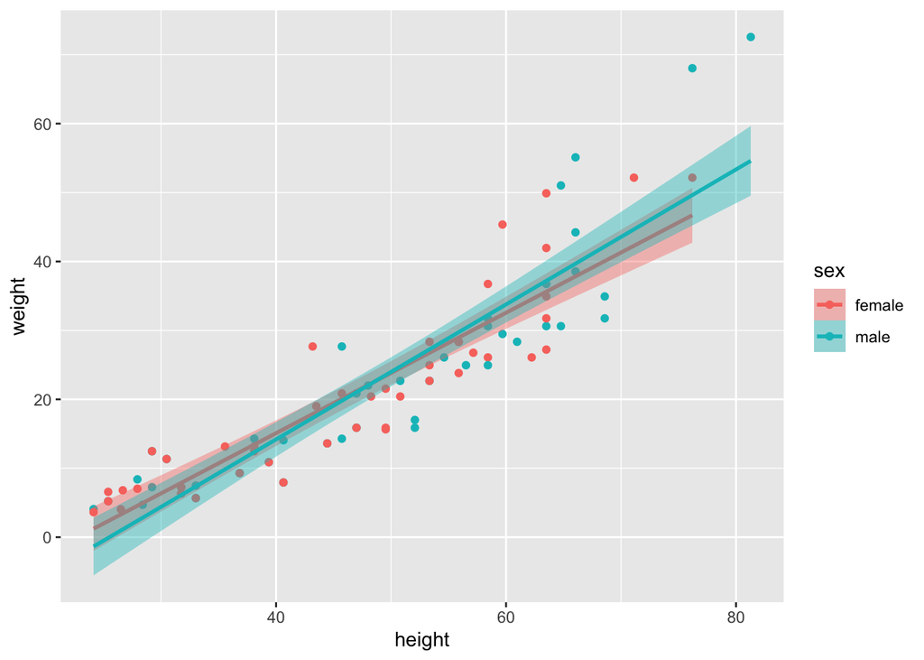

```r
dog_hw |>
  ggplot(aes(x = height, y = weight, colour = sex, fill = sex)) +
  geom_point() +
  geom_smooth(method = "lm")
```